# TS Zillow Team Project

Oleksiy Anokhin

10/29/2020

### Intro

```r
# Install packages
library(tidyverse) # for general analysis
library(fpp)
# library(fpp2)
library(fpp3) # for predictions
# Important notice: the latest package here is fpp3, but it does not work well sometimes with 'ts' data.
# https://stackoverflow.com/questions/64348121/error-objects-of-type-ts-not-supported-by-autoplot-cannot-knit-rmarkdown-pack
# For example, I cannot use 'autoplot()' function for such data
# Hence, I will use fpp2 for this assignment
library(ggthemes) # for beautiful themes
# library(tinytex) # for pdf documents
# library(highcharter) # for beautiful charts
library(TSA) # for TS analysis
# library(readxl) # for xls files
library(kableExtra) # for beautiful tables
library(lubridate) # for time data
library(tsibble) # for tsiblle data format
# library(plotly) # for interactive charts
library(caret) # for modeling
library(prophet) # for TS analysis
library(tibbletime)

# Set a theme
theme_set(theme_minimal())

# Remove scientific notations for prices
options(scipen = 999)
```

### Full data

#### Import data

[Prophet](https://facebook.github.io/prophet/) is a procedure for forecasting time series data based on an additive model where non-linear trends are fit with yearly, weekly, and daily seasonality, plus holiday effects. It works best with time series that have strong seasonal effects and several seasons of historical data. Prophet is robust to missing data and shifts in the trend, and typically handles outliers well.

```r
# Read data
chicago <- read_csv("Zillow monthly raw data (full).csv")

# Check dimensions
dim(chicago)
```

```
## [1] 120 156
```

#### Data manipulation

```r
# Read data
chicago <- chicago %>% filter(RegionName == "Chicago, IL")

# Check dimensions
dim(chicago)
```

```
## [1]   1 156
```

```r
# Convert data from wide to long format for proper analysis
chicago <- chicago %>% gather(key = "Date", value = "Price", -RegionID:-StateName) %>%
                              dplyr::select(RegionName, Date, Price) %>%
                              rename(Metro_area = RegionName, Median_price = Price)

# Check dimensions
dim(chicago)
```

```
## [1] 151   3
```

```r
# Print
kable(head(chicago, n = 5)) %>% kable_styling()
```

| Metro_area | Date | Median_price |
| --- | --- | --- |
| Chicago, IL | 2/29/08 | 250000 |
| Chicago, IL | 3/31/08 | 246000 |
| Chicago, IL | 4/30/08 | 249000 |
| Chicago, IL | 5/31/08 | 250000 |
| Chicago, IL | 6/30/08 | 255000 |

The `ds` column should be `YYYY-MM-DD` for a date, or `YYYY-MM-DD HH:MM:SS` for a `timestamp`.

```r
# Convert date from character to date
chicago$Date <- mdy(chicago$Date)

# Print
kable(head(chicago, n = 5)) %>% kable_styling()
```

| Metro_area | Date | Median_price |
| --- | --- | --- |
| Chicago, IL | 2008-02-29 | 250000 |
| Chicago, IL | 2008-03-31 | 246000 |
| Chicago, IL | 2008-04-30 | 249000 |
| Chicago, IL | 2008-05-31 | 250000 |
| Chicago, IL | 2008-06-30 | 255000 |

```r
# Drop Metro area column
chicago <- chicago %>% dplyr::select(Date, Median_price)

# Print
kable(head(chicago, n = 5)) %>% kable_styling()
```

| Date | Median_price |
| --- | --- |
| 2008-02-29 | 250000 |
| 2008-03-31 | 246000 |
| 2008-04-30 | 249000 |
| 2008-05-31 | 250000 |
| 2008-06-30 | 255000 |

```r
# Rename columns for Prophet analysis
chicago_prophet <- chicago %>% rename(ds = Date, y = Median_price)

# Print
kable(head(chicago_prophet, n = 5)) %>% kable_styling()
```

| ds | y |
| --- | --- |
| 2008-02-29 | 250000 |
| 2008-03-31 | 246000 |
| 2008-04-30 | 249000 |
| 2008-05-31 | 250000 |
| 2008-06-30 | 255000 |

#### Modelling

We call the `prophet` function to fit the model. The first argument is the historical dataframe. Additional arguments control how Prophet fits the data and are described in later pages of this documentation.

```r
# Fit the model
model1 <- prophet(chicago_prophet)

# Print
summary(model1)
```

```
##                         Length Class      Mode
## growth                    1    -none-     character
## changepoints             25    POSIXct    numeric
## n.changepoints            1    -none-     numeric
## changepoint.range         1    -none-     numeric
## yearly.seasonality        1    -none-     character
## weekly.seasonality        1    -none-     character
## daily.seasonality         1    -none-     character
## holidays                  0    -none-     NULL
## seasonality.mode          1    -none-     character
## seasonality.prior.scale   1    -none-     numeric
## changepoint.prior.scale   1    -none-     numeric
## holidays.prior.scale      1    -none-     numeric
## mcmc.samples              1    -none-     numeric
## interval.width            1    -none-     numeric
## uncertainty.samples       1    -none-     numeric
## specified.changepoints    1    -none-     logical
## start                     1    POSIXct    numeric
## y.scale                   1    -none-     numeric
## logistic.floor            1    -none-     logical
## t.scale                   1    -none-     numeric
## changepoints.t           25    -none-     numeric
## seasonalities             1    -none-     list
## extra_regressors          0    -none-     list
## country_holidays          0    -none-     NULL
## stan.fit                  4    -none-     list
## params                    5    -none-     list
## history                   5    tbl_df     list
## history.dates           151    POSIXct    numeric
## train.holiday.names       0    -none-     NULL
## train.component.cols      3    data.frame list
## component.modes           2    -none-     list
## fit.kwargs                0    -none-     list
```

Predictions are made on a dataframe with a column `ds` containing the dates for which predictions are to be made. The `make_future_dataframe` function takes the model object and a number of periods to forecast and produces a suitable dataframe. By default it will also include the historical dates so we can evaluate in-sample fit.

```r
# Create a forecast
future <- make_future_dataframe(model1, periods = 12)

# Print last 5 rows
tail(future, 12)
```

```
##             ds
## 152 2020-09-01
## 153 2020-09-02
## 154 2020-09-03
## 155 2020-09-04
## 156 2020-09-05
## 157 2020-09-06
## 158 2020-09-07
## 159 2020-09-08
## 160 2020-09-09
## 161 2020-09-10
## 162 2020-09-11
## 163 2020-09-12
```

#### Forecasting

As with most modeling procedures in R, we use the generic `predict` function to get our forecast. The forecast object is a dataframe with a column `yhat` containing the forecast. It has additional columns for uncertainty intervals and seasonal components.

```r
# Create a forecast
forecast1 <- predict(model1, future)

# Print
tail(forecast1[c('ds', 'yhat', 'yhat_lower', 'yhat_upper')])
```

```
##             ds     yhat yhat_lower yhat_upper
## 158 2020-09-07 272530.2   265235.5   279986.4
## 159 2020-09-08 272861.4   264769.9   280017.7
## 160 2020-09-09 272799.2   265511.0   280643.9
## 161 2020-09-10 272351.0   264950.7   280526.6
## 162 2020-09-11 271534.4   264143.1   279503.2
## 163 2020-09-12 270376.6   262455.0   278188.1
```

You can use the generic `plot` function to plot the forecast, by passing in the model and the forecast dataframe.

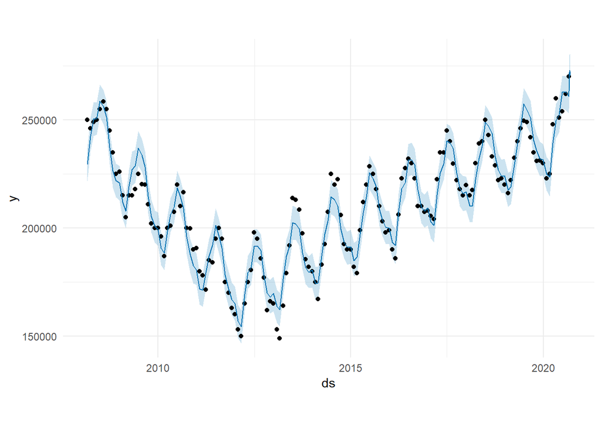

```r
# Plot the model
plot(model1, forecast1)
```

#### Trend and seasonality

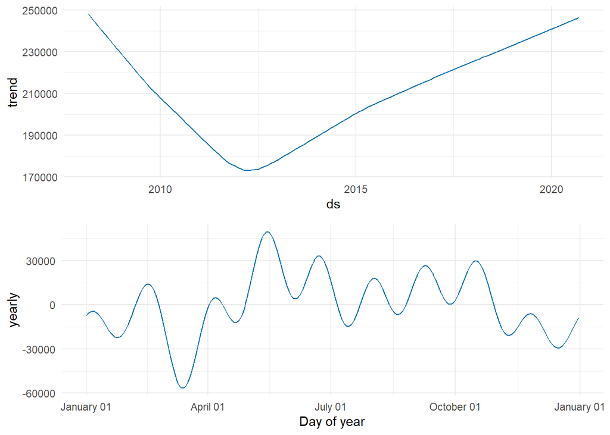

```r
# Analyze components
prophet_plot_components(model1, forecast1)
```

Prophet will by default fit weekly and yearly seasonalities, if the time series is more than two cycles long. It will also fit daily seasonality for a sub-daily time series. You can add other seasonalities (monthly, quarterly, hourly) using the add_seasonality function (R).

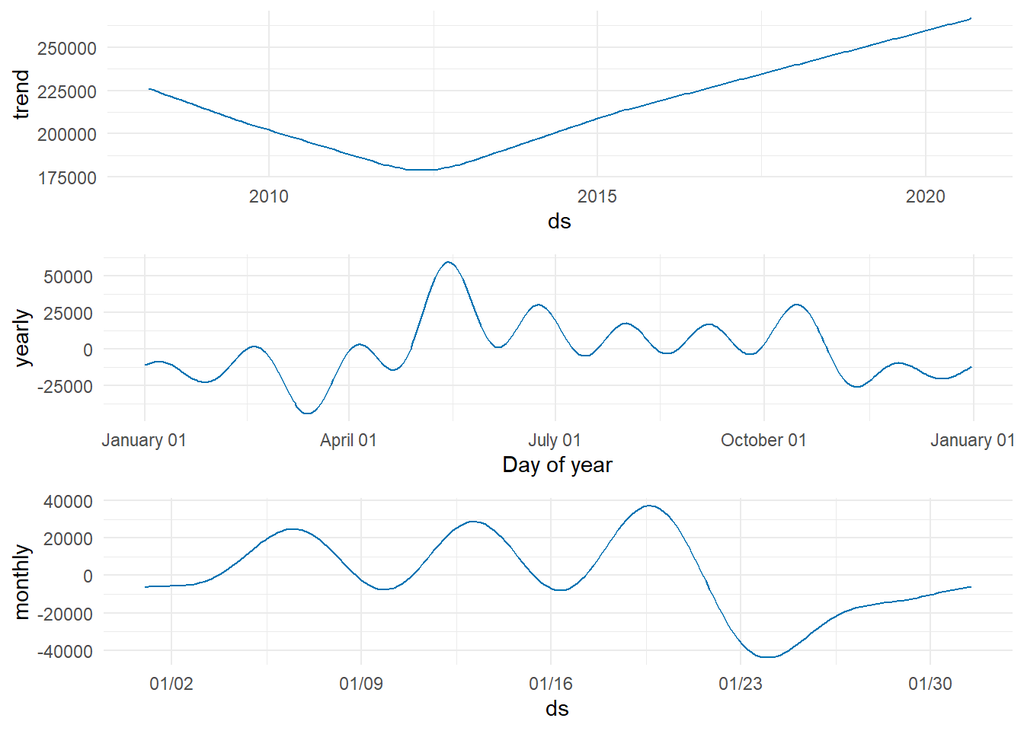

```r
# Remove weekly seasonality
model1 <- prophet(weekly.seasonality = FALSE)

# Add monthly seasonality
model1 <- add_seasonality(model1, name = "monthly", period = 30.5, fourier.order = 5)

# Fit the model
model1 <- fit.prophet(model1, chicago_prophet)

# Create a forecast
forecast1 <- predict(model1, future)

# Plot a forecast
prophet_plot_components(model1, forecast1)
```

#### Cross-validation

Prophet includes functionality for time series cross validation to measure forecast error using historical data. This is done by selecting cutoff points in the history, and for each of them fitting the model using data only up to that cutoff point. We can then compare the forecasted values to the actual values.

This cross validation procedure can be done automatically for a range of historical cutoffs using the `cross_validation` function. We specify the forecast horizon (`horizon`), and then optionally the size of the initial training period (`initial`) and the spacing between cutoff dates (`period`). By default, the initial training period is set to three times the horizon, and cutoffs are made every half a horizon.

The output of `cross_validation` is a dataframe with the true values y and the out-of-sample forecast values yhat, at each simulated forecast date and for each cutoff date. In particular, a forecast is made for every observed point between cutoff and cutoff + horizon. This dataframe can then be used to compute error measures of `yhat` vs. `y`.

```r
# Cross-validate the model
model1_cv <- cross_validation(model1, horizon = 365/12, units = "days", period = 365/12, initial = 365/12 * 12 * 3)
```

```r
# Print
model1_cv
```

```
## # A tibble: 114 x 6
##         y ds                     yhat yhat_lower yhat_upper cutoff
##     <dbl> <dttm>                <dbl>      <dbl>      <dbl> <dttm>
##  1 171500 2011-03-31 00:00:00 192112.    191557.    192619. 2011-03-04 12:00:00
##  2 185000 2011-04-30 00:00:00 188287.    186935.    189570. 2011-04-03 22:00:00
##  3 184000 2011-05-31 00:00:00 171961.    170602.    173260. 2011-05-04 08:00:00
##  4 195000 2011-06-30 00:00:00 207175.    205448.    208831. 2011-06-03 18:00:00
##  5 200000 2011-07-31 00:00:00 167641.    165915.    169527. 2011-07-04 04:00:00
##  6 195000 2011-08-31 00:00:00 204865.    201588.    208489. 2011-08-03 14:00:00
##  7 175000 2011-09-30 00:00:00 174164.    171063.    177346. 2011-09-03 00:00:00
##  8 170000 2011-10-31 00:00:00 182785.    179431.    186067. 2011-10-03 10:00:00
##  9 163000 2011-11-30 00:00:00 165827.    162679.    169058. 2011-11-02 20:00:00
## 10 160000 2011-12-31 00:00:00 168821.    165530.    172057. 2011-12-03 06:00:00
## # ... with 104 more rows
```

#### CV plot

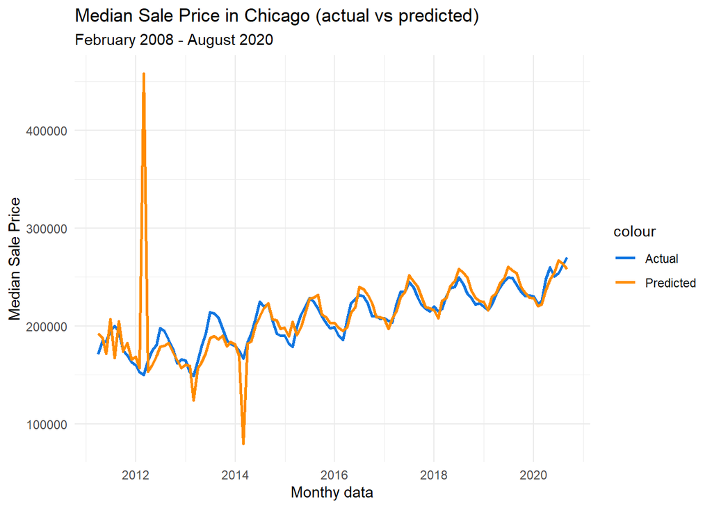

```r
# Define colors manually
colors <- c("Actual" = "#1277e1", "Predicted" = "darkorange")

# Plot data
ggplot(model1_cv, aes(x = ds)) + geom_line(aes(y = y, color = "Actual"), size = 1) +
                                 geom_line(aes(y = yhat, color = "Predicted"), size = 1) +
                                 labs(title = "Median Sale Price in Chicago (actual vs predicted)", subtitle = "February 2008 - August 2020") +
                                 xlab("Monthy data") +
                                 ylab("Median Sale Price") +
                                 scale_color_manual(values = colors)
```

### Short data

#### Import data

```r
# Read data
chicago_short <- read_csv("Zillow monthly raw data (since March 2013).csv")

# Check dimensions
dim(chicago_short)
```

```
## [1] 120  95
```

#### Data manipulation

```r
# Read data
chicago_short <- chicago_short %>% filter(RegionName == "Chicago, IL")

# Check dimensions
dim(chicago_short)
```

```
## [1]  1 95
```

```r
# Convert data from wide to long format for proper analysis
chicago_short <- chicago_short %>% gather(key = "Date", value = "Price", -RegionID:-StateName) %>%
                                   dplyr::select(RegionName, Date, Price) %>%
                                   rename(Metro_area = RegionName, Median_price = Price)

# Check dimensions
dim(chicago_short)
```

```
## [1] 90  3
```

```r
# Print
kable(head(chicago_short, n = 5)) %>% kable_styling()
```

| Metro_area | Date | Median_price |
| --- | --- | --- |
| Chicago, IL | 3/31/2013 | 164000 |
| Chicago, IL | 4/30/2013 | 179000 |
| Chicago, IL | 5/31/2013 | 192000 |
| Chicago, IL | 6/30/2013 | 213750 |
| Chicago, IL | 7/31/2013 | 213000 |

The `ds` column should be `YYYY-MM-DD` for a date, or `YYYY-MM-DD HH:MM:SS` for a `timestamp`.

```r
# Convert date from character to date
chicago_short$Date <- mdy(chicago_short$Date)

# Print
kable(head(chicago_short, n = 5)) %>% kable_styling()
```

| Metro_area | Date | Median_price |
| --- | --- | --- |
| Chicago, IL | 2013-03-31 | 164000 |
| Chicago, IL | 2013-04-30 | 179000 |
| Chicago, IL | 2013-05-31 | 192000 |
| Chicago, IL | 2013-06-30 | 213750 |
| Chicago, IL | 2013-07-31 | 213000 |

```r
# Drop Metro area column
chicago_short <- chicago_short %>% dplyr::select(Date, Median_price)

# Print
kable(head(chicago_short, n = 5)) %>% kable_styling()
```

| Date | Median_price |
| --- | --- |
| 2013-03-31 | 164000 |
| 2013-04-30 | 179000 |
| 2013-05-31 | 192000 |
| 2013-06-30 | 213750 |
| 2013-07-31 | 213000 |

```r
# Rename columns for Prophet analysis
chicago_short_prophet <- chicago_short %>% rename(ds = Date, y = Median_price)

# Print
kable(head(chicago_short_prophet, n = 5)) %>% kable_styling()
```

| ds | y |
| --- | --- |
| 2013-03-31 | 164000 |
| 2013-04-30 | 179000 |
| 2013-05-31 | 192000 |
| 2013-06-30 | 213750 |
| 2013-07-31 | 213000 |

#### Modelling

We call the `prophet` function to fit the model. The first argument is the historical dataframe. Additional arguments control how Prophet fits the data and are described in later pages of this documentation.

```r
# Fit the model
model2 <- prophet(chicago_short_prophet)

# Print
summary(model2)
```

```
##                         Length Class      Mode
## growth                   1     -none-     character
## changepoints            25     POSIXct    numeric
## n.changepoints           1     -none-     numeric
## changepoint.range        1     -none-     numeric
## yearly.seasonality       1     -none-     character
## weekly.seasonality       1     -none-     character
## daily.seasonality        1     -none-     character
## holidays                 0     -none-     NULL
## seasonality.mode         1     -none-     character
## seasonality.prior.scale  1     -none-     numeric
## changepoint.prior.scale  1     -none-     numeric
## holidays.prior.scale     1     -none-     numeric
## mcmc.samples             1     -none-     numeric
## interval.width           1     -none-     numeric
## uncertainty.samples      1     -none-     numeric
## specified.changepoints   1     -none-     logical
## start                    1     POSIXct    numeric
## y.scale                  1     -none-     numeric
## logistic.floor           1     -none-     logical
## t.scale                  1     -none-     numeric
## changepoints.t          25     -none-     numeric
## seasonalities            1     -none-     list
## extra_regressors         0     -none-     list
## country_holidays         0     -none-     NULL
## stan.fit                 4     -none-     list
## params                   5     -none-     list
## history                  5     tbl_df     list
## history.dates           90     POSIXct    numeric
## train.holiday.names      0     -none-     NULL
## train.component.cols     3     data.frame list
## component.modes          2     -none-     list
## fit.kwargs               0     -none-     list
```

Predictions are made on a dataframe with a column `ds` containing the dates for which predictions are to be made. The `make_future_dataframe` function takes the model object and a number of periods to forecast and produces a suitable dataframe. By default it will also include the historical dates so we can evaluate in-sample fit.

We have 90 data points in total since 2013.

```r
# Create a forecast
future_short <- make_future_dataframe(model2, periods = 12)

# Print last 5 rows
tail(future_short, 12)
```

```
##             ds
## 91  2020-09-01
## 92  2020-09-02
## 93  2020-09-03
## 94  2020-09-04
## 95  2020-09-05
## 96  2020-09-06
## 97  2020-09-07
## 98  2020-09-08
## 99  2020-09-09
## 100 2020-09-10
## 101 2020-09-11
## 102 2020-09-12
```

#### Forecasting

As with most modeling procedures in R, we use the generic `predict` function to get our forecast. The forecast object is a dataframe with a column `yhat` containing the forecast. It has additional columns for uncertainty intervals and seasonal components.

```r
# Create a forecast
forecast2 <- predict(model2, future_short)

# Print
head(forecast2[c('ds', 'yhat', 'yhat_lower', 'yhat_upper')])
```

```
##           ds     yhat yhat_lower yhat_upper
## 1 2013-03-31 179078.6   172400.1   186010.2
## 2 2013-04-30 192016.6   185905.1   198551.4
## 3 2013-05-31 195618.6   189435.1   202169.0
## 4 2013-06-30 205435.5   198602.2   212239.6
## 5 2013-07-31 204627.3   198001.2   211472.1
## 6 2013-08-31 201317.6   194756.7   208034.8
```

You can use the generic `plot` function to plot the forecast, by passing in the model and the forecast dataframe.

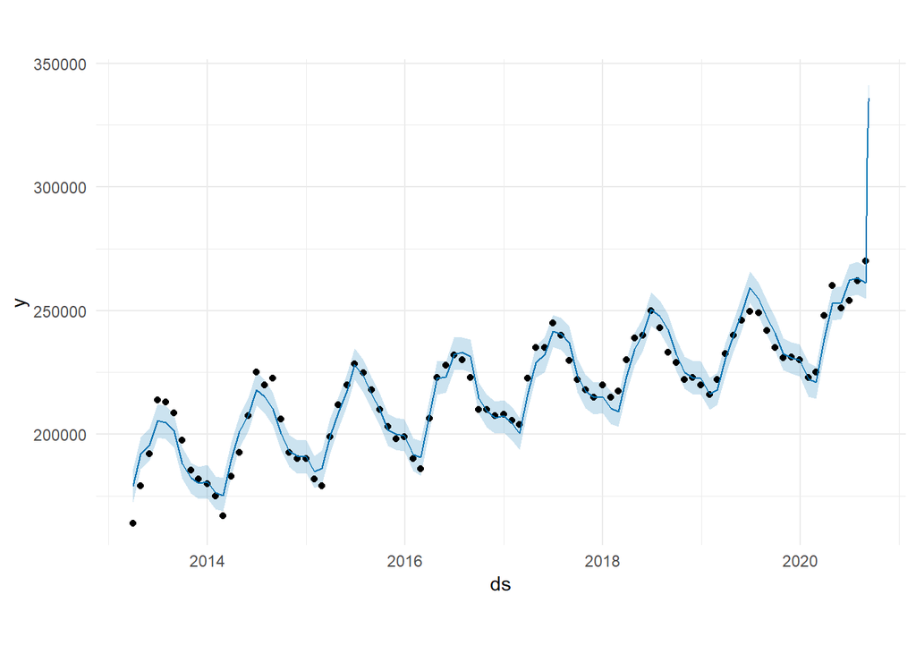

```r
# Plot the model
plot(model2, forecast2)
```

#### Trend and seasonality

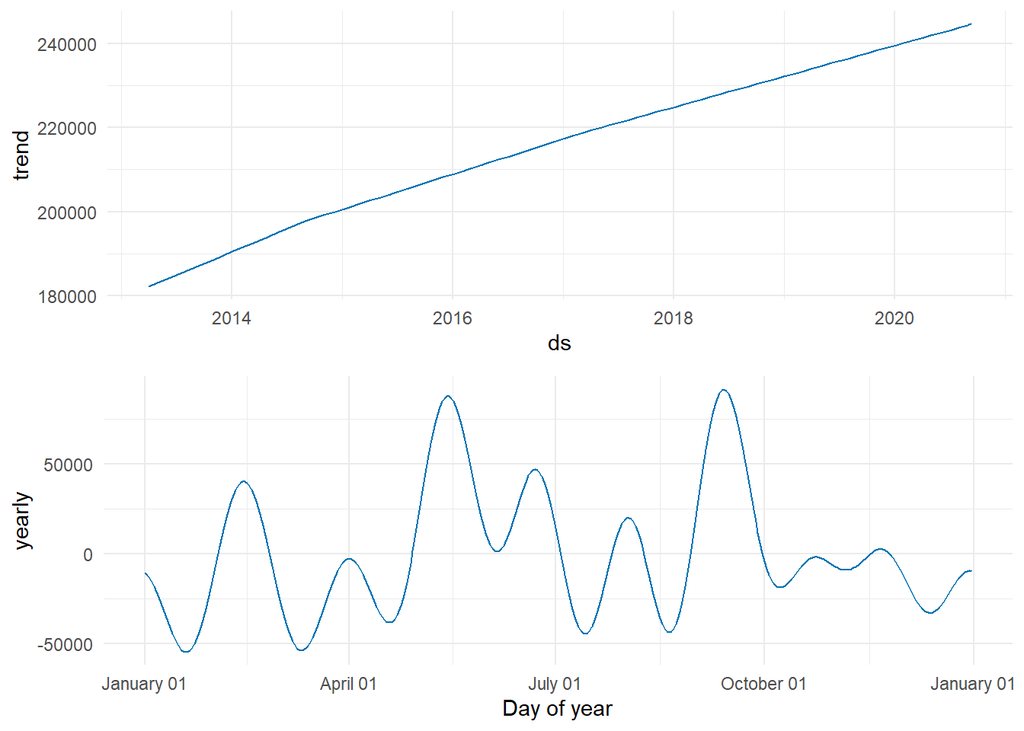

```r
# Analyze components
prophet_plot_components(model2, forecast2)
```

Prophet will by default fit weekly and yearly seasonalities, if the time series is more than two cycles long. It will also fit daily seasonality for a sub-daily time series. You can add other seasonalities (monthly, quarterly, hourly) using the add_seasonality function (R).

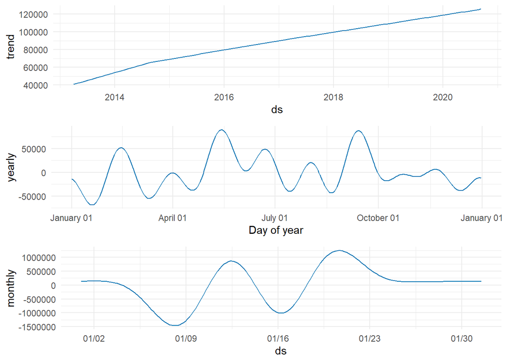

```r
# Remove weekly seasonality
model2 <- prophet(weekly.seasonality = FALSE)

# Add monthly seasonality
model2 <- add_seasonality(model2, name = "monthly", period = 30.5, fourier.order = 5)

# Fit the model
model2 <- fit.prophet(model2, chicago_short_prophet)

# Create a forecast
forecast2 <- predict(model2, future_short)

# Plot a forecast
prophet_plot_components(model2, forecast2)
```

#### Cross-validation

Prophet includes functionality for time series cross validation to measure forecast error using historical data. This is done by selecting cutoff points in the history, and for each of them fitting the model using data only up to that cutoff point. We can then compare the forecasted values to the actual values.

This cross validation procedure can be done automatically for a range of historical cutoffs using the `cross_validation` function. We specify the forecast horizon (`horizon`), and then optionally the size of the initial training period (`initial`) and the spacing between cutoff dates (`period`). By default, the initial training period is set to three times the horizon, and cutoffs are made every half a horizon.

The output of `cross_validation` is a dataframe with the true values y and the out-of-sample forecast values yhat, at each simulated forecast date and for each cutoff date. In particular, a forecast is made for every observed point between cutoff and cutoff + horizon. This dataframe can then be used to compute error measures of `yhat` vs. `y`.

```r
# Cross-validate the model
model2_cv <- cross_validation(model2, horizon = 365/12, units = "days", period = 365/12, initial = 365/12 * 12 * 3)
```

```r
# Print
model2_cv
```

```
## # A tibble: 53 x 6
##         y ds                     yhat yhat_lower yhat_upper cutoff
##     <dbl> <dttm>                <dbl>      <dbl>      <dbl> <dttm>
##  1 223000 2016-04-30 00:00:00 216234.    213479.    219086. 2016-04-01 22:00:00
##  2 227750 2016-05-31 00:00:00 228135.    225942.    230436. 2016-05-02 08:00:00
##  3 232000 2016-06-30 00:00:00 262688.    260772.    264603. 2016-06-01 18:00:00
##  4 230000 2016-07-31 00:00:00 244280.    240519.    248108. 2016-07-02 04:00:00
##  5 223000 2016-08-31 00:00:00 236233.    232299.    239668. 2016-08-01 14:00:00
##  6 210000 2016-09-30 00:00:00 225487.    221123.    229773. 2016-09-01 00:00:00
##  7 210000 2016-10-31 00:00:00 204449.    199989.    209192. 2016-10-01 10:00:00
##  8 207500 2016-11-30 00:00:00 206837.    202249.    211103. 2016-10-31 20:00:00
##  9 208000 2016-12-31 00:00:00 198002.    193478.    202345. 2016-12-01 06:00:00
## 10 205500 2017-01-31 00:00:00 187383.    182598.    192101. 2016-12-31 16:00:00
## # ... with 43 more rows
```

#### CV plot

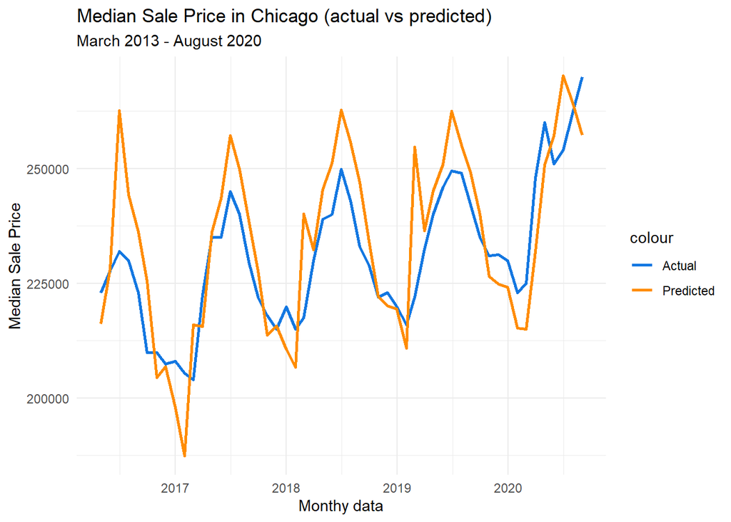

```r
# Define colors manually
colors <- c("Actual" = "#1277e1", "Predicted" = "darkorange")

# Plot data
ggplot(model2_cv, aes(x = ds)) + geom_line(aes(y = y, color = "Actual"), size = 1) +
                                 geom_line(aes(y = yhat, color = "Predicted"), size = 1) +
                                 labs(title = "Median Sale Price in Chicago (actual vs predicted)", subtitle = "March 2013 - August 2020") +
                                 xlab("Monthy data") +
                                 ylab("Median Sale Price") +
                                 scale_color_manual(values = colors)
```

### Additional information

Prophet has some problems with cross validation of months, it is only available for days. There are multiple issues on GitHub about it:

- https://github.com/facebook/prophet/issues/1351
- https://github.com/facebook/prophet/issues/949
- https://github.com/facebook/prophet/issues/586

Cross-validation:

- https://facebook.github.io/prophet/docs/diagnostics.html
- https://stackoverflow.com/questions/64959952/evaluating-prophet-model-in-r-using-cross-validation